# Exploring the BRFSS data

## Setup

### Load packages

```r
library(ggplot2)
library(dplyr)
library(knitr)
```

### Load data

```r
load("brfss2013.RData")
```

## Part 1: Data

The BRFSS is a yearly health survey developed by the CDC, administered over the telephone by United States state health departments, interviewing more than 400,000 adults per year in all 50 states and 4 U.S. territories.

The survey consists of a “core” group of questions that must be asked of all survey participants, regardless of state. Beyond that the state agency has additional optional general modules and state specific modules that they may use. Participants are chosen by randomly dialed phone numbers.

The sampling method utilized for this survey is simple random. The optional modules are only able to be generalized to the states that opted to use them. The “core” mandatory component of the survey, however, can be generalized to the US population, with some caveats.

The provided data set filters for only surveys completed or partially completed, so analysis on how completion rates are affected by various factors and how that may impact the generalizability of the data can not be completed.

```r
kable(brfss2013 %>%
  group_by(dispcode) %>%
  summarise(count = n()))
```

| dispcode | count |
| --- | --- |
| Completed interview | 433222 |
| Partially completed interview | 58548 |
| NA | 5 |

In addition to the above point, while all states participate in the survey, the amount of surveys administered depends on the funding and resources available to the individual state agencies. This has resulted in a considerable disproportion of responses based on population. We can see evidence of this skew by noting that Kansas and Nebraska have the 2nd and 3rd highest number of observations in this data set, though they are ranked 34th and 37th respectively in population according to the 2013 census. For comparison, Arizona, with the 15th largest population, has the 2nd least number of observations in this data set, beat out only by Guam for the bottom ranking.

```r
topstates <- brfss2013 %>%
  group_by(X_state) %>%
  summarise(count = n()) %>%
  filter( count > 1)
topstates <- topstates[order(-topstates$count),]
kable(head(topstates, 5), caption = "Top 5 States by Observations")
```

Top 5 States by Observations

| X_state | count |
| --- | --- |
| Florida | 33668 |
| Kansas | 23282 |
| Nebraska | 17139 |
| Massachusetts | 15071 |
| Minnesota | 14340 |

```r
kable(tail(topstates, 5), caption = "Bottom 5 States by Observations")
```

Bottom 5 States by Observations

| X_state | count |
| --- | --- |
| Nevada | 5101 |
| District of Columbia | 4931 |
| Alaska | 4578 |
| Arizona | 4253 |
| Guam | 1897 |

Another example of potential bias that may impact generalizability is land line vs cell phone surveys. The surveys are conducted in such a way that all land line surveys are for individuals who only have a land line, and all cellphone surveys are for individuals who only have a cell phone. As seen in the table below, there is a drastically lower population of completed cell phone surveys compared to land line, which may introduce a bias to the data set.

```r
kable(brfss2013 %>%
  group_by(cellfon3) %>%
  summarise(count = n()))
```

| cellfon3 | count |
| --- | --- |
| Not a cellular phone | 356624 |
| NA | 135151 |

The CDC does, however, leverage methods of weighting results based on demographics and other factors to attain more reliable generalizability for the survey results.

As the data collection process did not included an experiment with controls and variable manipulation, it is not possible to use any of this data to draw causal inferences.

## Part 2: Research questions

**Research question 1:**

Is there a relationship between reporting poor mental health and reporting poor physical health?

It is the author’s perception that poor mental and physical health likely have a high level of coincidence, and this data set is an excellent source to dig in to that question.

**Research question 2:**

Which participants are more likely to report that poor health prevented them from completing normal daily activities, participants who ONLY indicated mental health problems or participants who ONLY indicated physical health problems?

Essentially this is an interesting way to begin exploring the idea of how disabling poor mental health can be compared to poor physical health.

**Research question 3:**

Controlling for poor physical health, is there a relationship between minutes of physical activity and reported number of days of poor mental health?

It is commonly held that excessive can help relieve stress and depression. This is an intriguing concept, and this data set allows for some exploration between those two variables, which may help to confirm those ideas.

## Part 3: Exploratory data analysis

**Research question 1:**

Is there a relationship between reporting poor mental health and reporting poor physical health?

```r
mentAndPhys <- brfss2013 %>%
  filter(!(is.na(menthlth)),!(is.na(physhlth))) %>%
  filter(!(menthlth == 0 & physhlth == 0)) %>%
  filter(menthlth <= 30, physhlth <= 30) %>%
  mutate(bothhlth = ifelse(physhlth > 0 & menthlth > 0, "BOTH", "EXCLUSIVE")) %>%
  mutate(mentcat = ifelse(menthlth < 8, "Less than 8", "More than 8")) %>%
  mutate(physcat = ifelse(physhlth <8, "Less than 8", "More than 8"))
```

In order to tackle this question, we isolate our data set to include only observations where participants indicated how many days out of the last 30 they were in poor mental health, and how many days out of the last 30 they were in poor physical health. We then filter out any observations where both questions were answered as 0 days.

```r
kable(mentAndPhys %>%
  group_by(bothhlth) %>%
  summarise(count = n(), percent = round(count/nrow(mentAndPhys)*100,2)))
```

| bothhlth | count | percent |
| --- | --- | --- |
| BOTH | 82028 | 34.55 |
| EXCLUSIVE | 155360 | 65.45 |

We can see from the above table that only just over 1/3 of participants who answered one of these questions as greater than 0 reported both poor and mental physical health.

Immediately it appears that these two variables might not be strongly related.

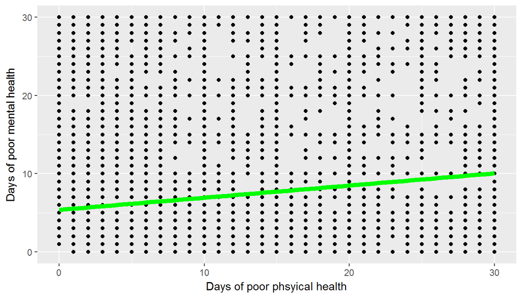

```r
ggplot(data = mentAndPhys, aes(x = physhlth, y = menthlth)) + geom_point() +
  geom_smooth(method = "lm", colour = "green", size = 2) +
  xlab("Days of poor phsyical health") +
  ylab("Days of poor mental health")
```

The above plot shows physical health on the x axis and mental health on the y axis, both in units of reported days of poor health.

Based on this plot, while there is no clear linear relationship in the points, the trend line does indicate that as days of poor physical health increases, mental health also tends to increase, though no causal inference can be drawn from this.

This implies a small correlation but I believe warrants further investigation.

**Research question 2:**

Which participants are more likely to report that poor health prevented them from completing normal daily activities, participants who ONLY indicated mental health problems, or participants who ONLY indicated physical health problems?

```r
mentAndPhysExc <- mentAndPhys %>%
  filter(bothhlth == "EXCLUSIVE", poorhlth < 30 & poorhlth >=0) %>%
  mutate(hlthprob = ifelse(menthlth > physhlth, "mental", "physical"))
```

For this question, we rely on the previously created variable “bothhlth” to indicate if an observation shows both poor mental and physical heath. We then filter to keep observations that only report one or the other. Finally we create the new data point “hlthprob” to simply indicate if the indicated problems were mental or physical.

```r
kable(mentAndPhysExc %>%
  group_by(hlthprob) %>%
  summarise(count = n(), meandays = mean(poorhlth), sddays = sd(poorhlth), meddays = median(poorhlth)))
```

| hlthprob | count | meandays | sddays | meddays |
| --- | --- | --- | --- | --- |
| mental | 62566 | 1.106224 | 3.409330 | 0 |
| physical | 82354 | 2.493528 | 4.931206 | 0 |

As seen in the table above, participants that only indicated mental health problems were prevented from doing regular daily activity an average of 1.1 days a month, where participants with physical health problems indicated 2.5 days per month being prevented from participating in regular activity.

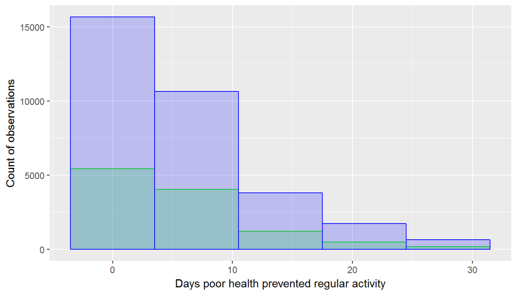

```r
mentAndPhysExcNonZero <- mentAndPhysExc %>%
  filter(poorhlth > 0)

ggplot(mentAndPhysExcNonZero, aes(x = poorhlth)) +
  geom_histogram(data = subset(mentAndPhysExcNonZero, hlthprob == "mental"), bins = 5, fill = "green", color = "green", alpha = 0.2)+
  geom_histogram(data = subset(mentAndPhysExcNonZero, hlthprob == "physical"), bins = 5, fill = "blue", color = "blue", alpha = 0.2)+
  xlab("Days poor health prevented regular activity") +
  ylab("Count of observations")
```

Indeed, in this stacked histogram we can see that there are much higher concentrations of participants with physical ailments reporting days of prevented regular activity. While we can not infer causality, the question was specifically worded to ask how many days being unwell prevented them from regular activity.

Further research and experimentation would be required to validate these results.

**Research question 3:**

Controlling for poor physical health, is there a relationship between minutes of physical activity and reported number of days of poor mental health?

```r
actAndMent <- brfss2013 %>%
  filter(!(is.na(pa1min_)), !(is.na(menthlth)), menthlth <= 30, pa1min_ <= 1000, physhlth == 0) %>%
  mutate(acthlthcat =
           ifelse(menthlth == 0 & pa1min_ == 0, "NoAct/GoodHlth",
            ifelse(menthlth > 0 & pa1min_ == 0, "NoAct/PoorHlth",
            ifelse(menthlth > 0 & pa1min_ > 0, "Act/PoorHlth",
            ifelse(menthlth == 0 & pa1min_ >0, "Act/GoodHlth", "ERROR")))))
```

The provided data set has a computed “Total minutes of physical activity” variable, which makes this analysis relatively straight forward. In order to prepare the data for this analysis, we first filter out observations where questions about minutes of activity, mental health, and physical health were not answered. We also filter out any observations where physical health was not at 0. To remove extreme outliers, we filter out any reports of more than 1000 minutes of excessive per week. In order to have a stronger basis of comparison, we want to look only at participants who don’t report days of physical illness.

We then create a new variable to categorize if a participant has any activity or no activity, and no days of poor mental health or days of poor mental health.

```r
kable(actAndMent %>%
  group_by(acthlthcat) %>%
  summarise(count = n(), percent = round(count/nrow(actAndMent)*100,2)))
```

| acthlthcat | count | percent |
| --- | --- | --- |
| Act/GoodHlth | 140359 | 73.67 |
| Act/PoorHlth | 40409 | 21.21 |
| NoAct/GoodHlth | 7817 | 4.10 |
| NoAct/PoorHlth | 1946 | 1.02 |

We can see that nearly 95% of participants indicated some level of physical activity.

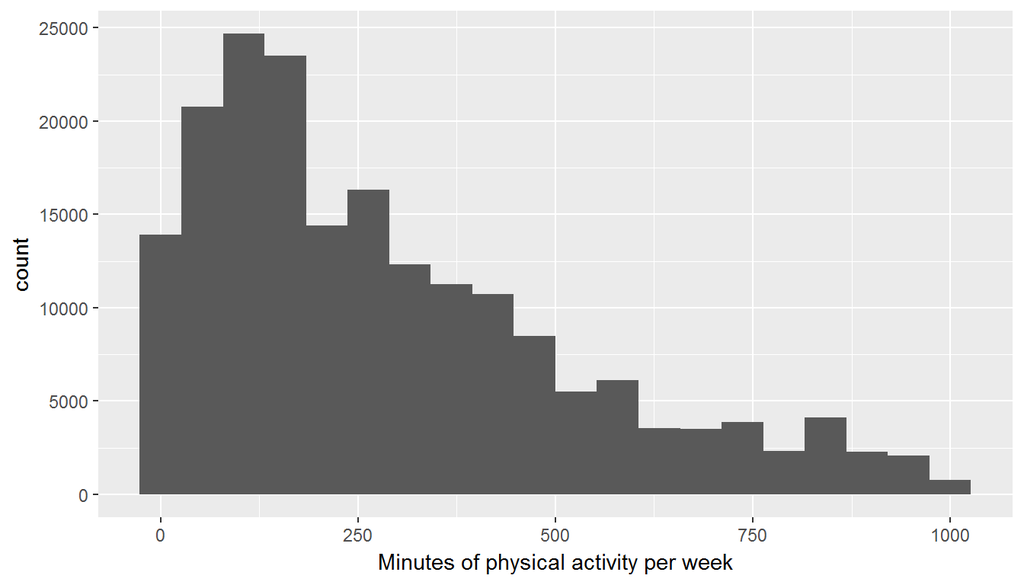

```r
ggplot(data = actAndMent, aes(x = pa1min_)) + geom_histogram(bins = 20)+
  xlab("Minutes of physical activity per week")
```

We see the histogram of reported minutes of physical activity is heavily right skewed, with most participants having 500 minutes or less of activity, which validates filter out reports of more than 1000 minutes.

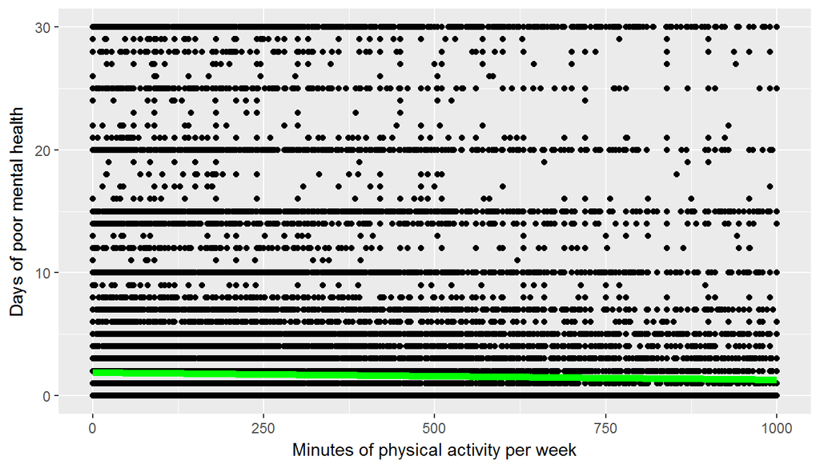

```r
ggplot(data = actAndMent, aes(x = pa1min_, y = menthlth)) + geom_point() +
  geom_smooth(method = "lm", colour = "green", size = 2) +
  xlab("Minutes of physical activity per week") +
  ylab("Days of poor mental health")
```

Finally, plotting the points, we do not see a strong relationship between the two data points, if any. We do see in the trend line that there appears to be a slight decrease in average days of poor mental health decreasing, but it is not by a notable amount.

Further research and experiments are warranted to look in to this question to determine through other methods if there is a provable relationship.